# Turismo en el Mercado Único y Libre de Cambios (MULC)

Ingresos y egresos de divisas vinculados al turismo en el mercado oficial de cambios.

El impacto del turismo en términos de ingresos y egresos de divisas puede ser analizado a partir de dos fuentes de información:

- La estimación del gasto turístico a partir de encuestas de demanda, el cual se publica dentro de las [estadísticas de Balanza de Pagos](https://www.indec.gob.ar/indec/web/Nivel4-Tema-3-35-45) que informa el INDEC trimestralmente y
- Las transacciones en divisas realizadas a través del Mercado Único y Libre de Cambios (MULC) en rubros vinculados al turismo, registradas por el [Banco Central de la República Argentina (BCRA)](http://www.bcra.gov.ar/PublicacionesEstadisticas/Estad%C3%ADsticas_Mercado_de_cambios.asp) de manera mensual.

En esta nota se presenta, en primer lugar, las transacciones en el mercado oficial registradas por el BCRA, describiendo sus características y sus principales resultados, que a su vez se plasman en el reporte [Turismo en el MULC](https://tableros.yvera.tur.ar/mulc.html). En una segunda sección se muestra la comparación de estos datos con los que provee la estimación de la Balanza de Pagos.

## ¿Qué es el turismo en el MULC?

El BCRA publica las estadísticas de las transacciones realizadas a través del MULC clasificadas dentro de la Cuenta Corriente, Cuenta Capital y Cuenta Financiera cambiarias. Dentro de la Cuenta Corriente, a su vez, se distingue entre operaciones de bienes y de servicios. Dentro de esta última categoría pueden seleccionarse dos rubros vinculados al turismo:

- **Viajes y otros pagos con tarjeta**, que incluye todas las transacciones internacionales realizadas por operadores turísticos locales, la compra/venta de divisas en billetes por parte de personas no residentes, los ingresos de divisas por compras realizadas por personas no residentes con tarjetas de crédito dentro de Argentina y los egresos de divisas por compras realizadas por residentes con tarjeta de crédito en el exterior. *Aquí cabe aclarar que no todas las transacciones con tarjeta de crédito corresponden a compras realizadas durante un viaje turístico, sino que pueden corresponder, por ejemplo, a compras con envío internacional o compras de servicios de streaming. Es importante tener en cuenta esta aclaración, dado que durante este informe nos referiremos a turismo y estos pagos estarán incluidos dentro de ese concepto.*
- **Servicios de transporte de pasajeros**, que incluye los ingresos de divisas por la compra de pasajes internacionales por parte de no residentes a empresas de transporte residentes y los egresos de divisas por la compra de pasajes internacionales por parte de residentes a empresas de transporte no residentes.

De esta manera se puede analizar la evolución mensual de los ingresos y egresos de divisas por turismo.

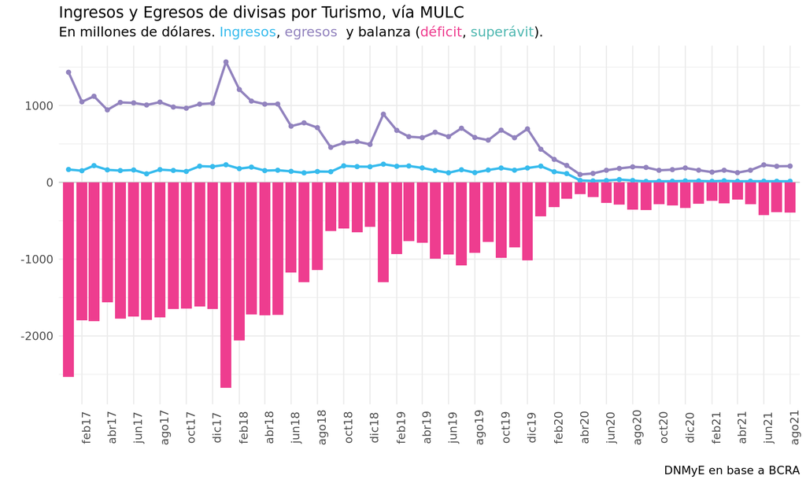

A su vez, se puede observar el aporte de los rubros turísticos al total de servicios

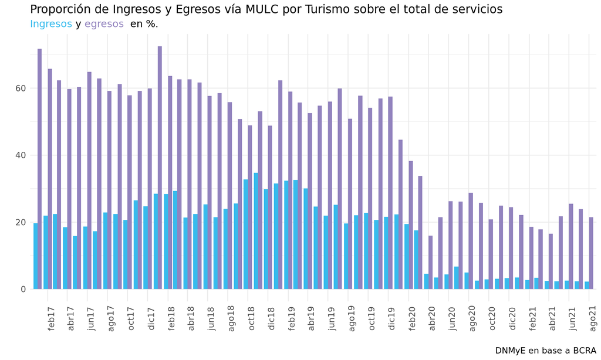

En la comparación con el resto de los rubros, vemos que, en el mes de agosto 2021, el turismo ocupó el puesto 9° dentro de los ingresos de divisas por servicios y el puesto 2° para los egresos.

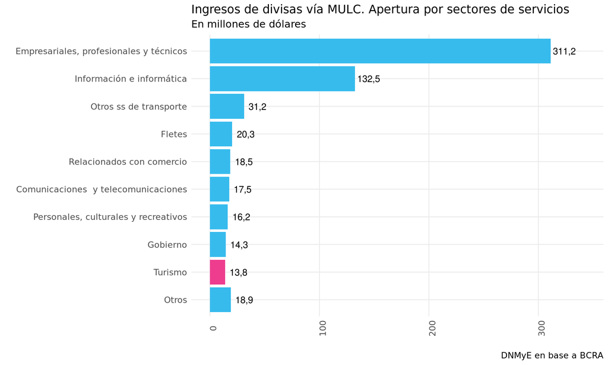

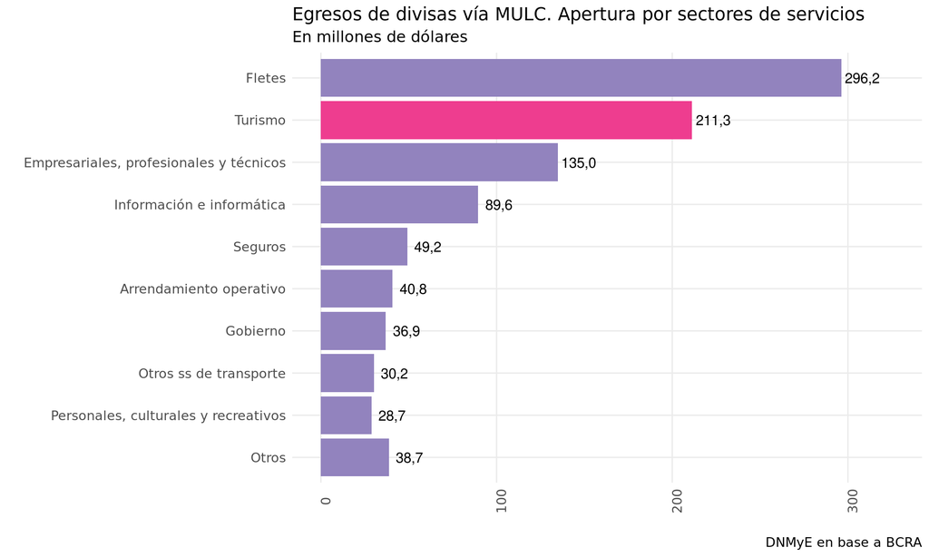

A su vez, se puede ver la evolución mensual de los conceptos que componen el rubro “Viajes y otros pagos con tarjeta”.

Según la apertura del rubro “Viajes y otros pagos con tarjeta”, se observa que tanto los ingresos como los egresos de divisas están principalmente explicados por las compras con tarjetas y en menor medida por las transacciones de los operadores turísticos locales.

En cuanto al rubro “Billetes - No Residentes”, los ingresos de divisas por este motivo (cambio de divisas por pesos argentinos realizado por turistas no residentes) es prácticamente nulo desde abril de 2020, mientras que los egresos (cambio de pesos argentinos por divisas) es prácticamente nulo desde noviembre de 2019. En ambos casos, impactó fundamentalmente la imposibilidad de operación de las casas de cambio como producto de las medidas de aislamiento social preventivo y obligatorio a partir de fines de marzo de 2020, y en el caso particular de los egresos, además impactaron las medidas de restricción cambiarias desde noviembre de 2019.

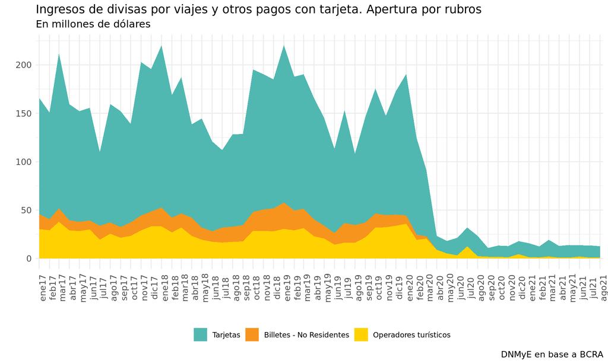

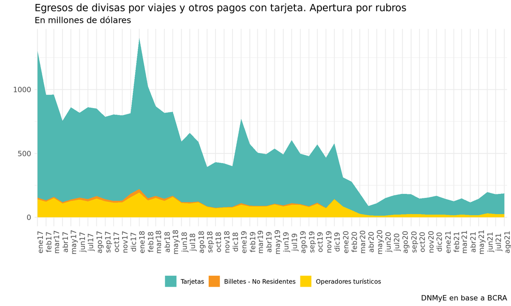

## MULC vs Balanza de Pagos

La Balanza de Pagos (“BP”) contiene, dentro de la cuenta corriente, dos cuentas vinculadas al turismo: “Cuenta Viajes” y “Cuenta Transporte de Pasajeros”. La Cuenta Viajes estima, en el crédito, el total de los ingresos monetarios debidos al turismo receptivo y, en el débito, el total de los egresos monetarios producidos por el turismo emisivo. Por su lado, la Cuenta Transporte de Pasajeros estima, en el crédito, los ingresos monetarios por las compras de pasajes internacionales que realizaron personas no residentes a empresas residentes en Argentina y, en el débito, los egresos monetarios por la compra de pasajes internacionales por parte de personas residentes en Argentina a empresas residentes en el exterior.

Dado que el MULC registra los ingresos/egresos de divisas vía el mercado oficial de cambios, en esta sección del informe se realiza una comparación entre las transacciones registradas por el MULC y el total estimado por la BP, a fin de conocer qué parte del turismo está generando divisas en el mercado formal, y qué parte se está volcando al mercado informal de cambios (mercado “negro” o “blue”).

Dado que la información de la BP se presenta una vez por trimestre, la comparación se realiza agrupando por trimestres los datos del BCRA.

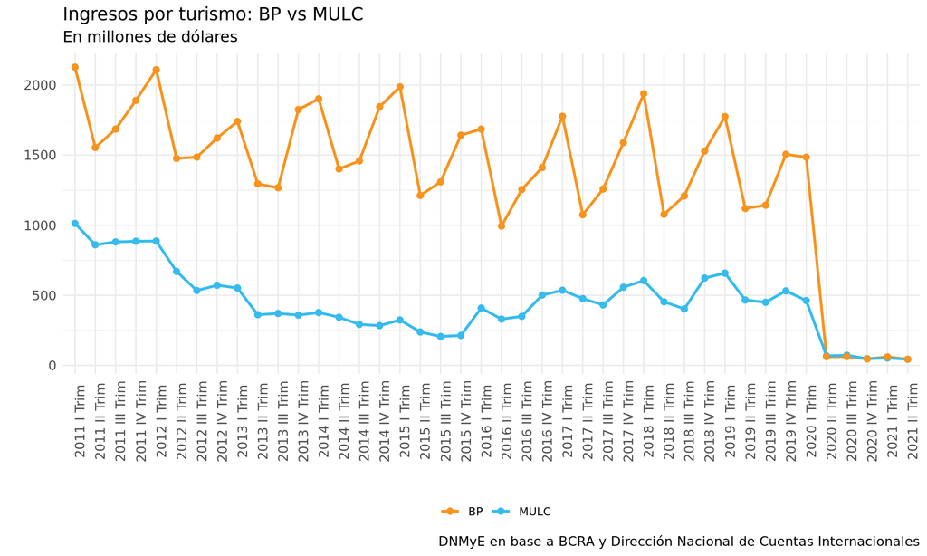

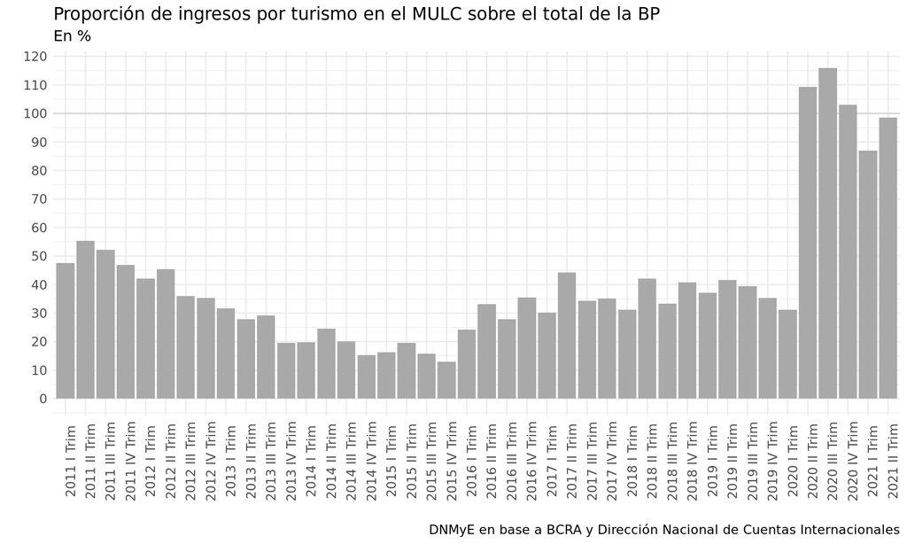

La proporción de los ingresos canalizados vía el mercado oficial es inusualmente alta en la actualidad con respecto a la historia reciente. La reducción de la movilidad de las personas y los cambios de comportamiento de los turistas, como producto de la pandemia, promovieron un mayor uso de tarjetas de crédito y el menor acceso a casas de cambio informales, aumentando la proporción de ingresos por turismo percibida por el MULC [^1].

Al igual que los ingresos, los egresos también muestran un comportamiento inusual en los últimos trimestres[^2].

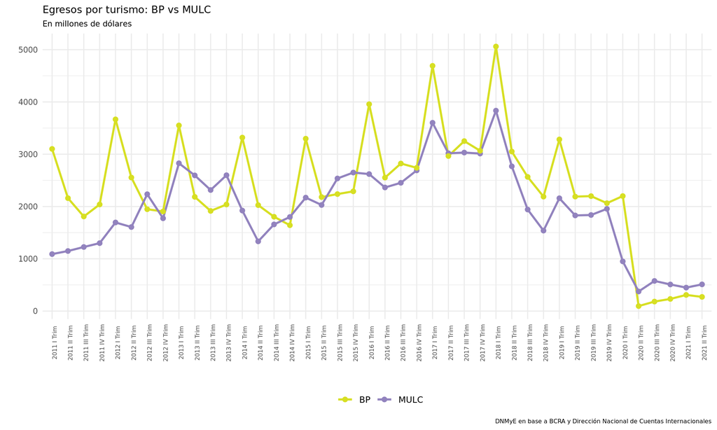

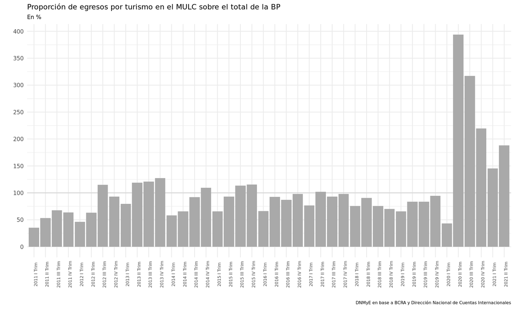

### Recurso - Turismo en el MULC

[**Reporte**](https://tableros.yvera.tur.ar/mulc.html)

[^1]: Es importante notar que los ingresos por turismo, a través del mercado oficial de cambios (MULC), siempre deberían ser menores, o al menos iguales, al total de ingresos por turismo que percibe la Argentina según la Balanza de Pagos. Sin embargo, en los trimestres 2, 3 y 4 del año 2020 la proporción MULC/BP es mayor al 100%. Esto es debido a las diferencias en cuanto a la metodología de registración de ambas fuentes de información y los desfasajes en la vuelta de los turistas no residentes a sus lugares de origen, producto de las restricciones al tránsito internacional por la pandemia por el virus COVID-19.
[^2]: Nuevamente, los egresos por turismo a través del mercado oficial de cambios (MULC) siempre deberían ser menores, o al menos iguales, al total de egresos por turismo de la Argentina según la Balanza de Pagos. Sin embargo, en repetidas ocasiones esto no es así, especialmente en los trimestres 2, 3 y 4 del año 2020 y el 1er trimestre del 2021. En el caso de los egresos, sucede que el componente turístico del MULC incluye pagos con tarjeta realizados por residentes en Argentina a residentes en el exterior y que pueden no ser gastos turísticos. Ejemplos de esto podrían ser los pagos de servicios de streaming. Por lo tanto, en los casos en que el ratio MULC/BP es mayor al 100% se evidencia que los gastos con tarjeta por motivos no turísticos aumentaron la componente “viajes y otros gastos con tarjeta” del MULC por encima de los gastos del turismo emisivo registrado por la BP. En los trimestres comprendidos en la pandemia por COVID-19, esta situación se refleja aún más debido a la reducción de cercana al 100% i.a. del turismo emisivo.